# Regression Models Course Project

Houmin Zhong

August 21, 2016

## Instruction

You work for Motor Trend, a magazine about the automobile industry. Looking at a data set of a collection of cars, they are interested in exploring the relationship between a set of variables and miles per gallon (MPG) (outcome). They are particularly interested in the following two questions:

1. Is an automatic or manual transmission better for MPG?
2. Quantify the MPG difference between automatic and manual transmissions?

### 1. Automatic or manual transmission comparison

```r
# load the dataset mtcars
data(mtcars)
mtcars$am<-factor(mtcars$am) # Convert numeric variable am to a factor variable
head(mtcars)
```

```
##                    mpg cyl disp  hp drat    wt  qsec vs am gear carb
## Mazda RX4         21.0   6  160 110 3.90 2.620 16.46  0  1    4    4
## Mazda RX4 Wag     21.0   6  160 110 3.90 2.875 17.02  0  1    4    4
## Datsun 710        22.8   4  108  93 3.85 2.320 18.61  1  1    4    1
## Hornet 4 Drive    21.4   6  258 110 3.08 3.215 19.44  1  0    3    1
## Hornet Sportabout 18.7   8  360 175 3.15 3.440 17.02  0  0    3    2
## Valiant           18.1   6  225 105 2.76 3.460 20.22  1  0    3    1
```

```r
str(mtcars) #exploratory data analyses
```

```
## 'data.frame':    32 obs. of  11 variables:
##  $ mpg : num  21 21 22.8 21.4 18.7 18.1 14.3 24.4 22.8 19.2 ...
##  $ cyl : num  6 6 4 6 8 6 8 4 4 6 ...
##  $ disp: num  160 160 108 258 360 ...
##  $ hp  : num  110 110 93 110 175 105 245 62 95 123 ...
##  $ drat: num  3.9 3.9 3.85 3.08 3.15 2.76 3.21 3.69 3.92 3.92 ...
##  $ wt  : num  2.62 2.88 2.32 3.21 3.44 ...
##  $ qsec: num  16.5 17 18.6 19.4 17 ...
##  $ vs  : num  0 0 1 1 0 1 0 1 1 1 ...
##  $ am  : Factor w/ 2 levels "0","1": 2 2 2 1 1 1 1 1 1 1 ...
##  $ gear: num  4 4 4 3 3 3 3 4 4 4 ...
##  $ carb: num  4 4 1 1 2 1 4 2 2 4 ...
```

```r
mean(mtcars$mpg[mtcars$am == "1"]) #finding mean mpg of manual cars
```

```
## [1] 24.39231
```

```r
sd(mtcars$mpg[mtcars$am == "1"]) #finding mpg standard deviation of manual cars
```

```
## [1] 6.166504
```

```r
mean(mtcars$mpg[mtcars$am == "0"]) #finding mean mpg of automatic cars
```

```
## [1] 17.14737
```

```r
sd(mtcars$mpg[mtcars$am == "0"]) #finding mpg standard deviation of automatic cars
```

```
## [1] 3.833966
```

```r
# t-test
# H_0: there is no significant difference in mpg between manual and automatic cars (H_0 = H_a). H_a: there is significant difference in mpg between manual and automatic cars (H_0 != H_a) with alpha = 0.05.
am.result<-t.test(mtcars$mpg[mtcars$am == "1"],mtcars$mpg[mtcars$am == "0"])
am.result
```

```
##
##  Welch Two Sample t-test
##
## data:  mtcars$mpg[mtcars$am == "1"] and mtcars$mpg[mtcars$am == "0"]
## t = 3.7671, df = 18.332, p-value = 0.001374
## alternative hypothesis: true difference in means is not equal to 0
## 95 percent confidence interval:
##   3.209684 11.280194
## sample estimates:
## mean of x mean of y
##  24.39231  17.14737
```

```r
print(paste0("p_value = ",am.result$p.value, ". Therefore, we reject H_0." ))
```

```
## [1] "p_value = 0.00137363833307103. Therefore, we reject H_0."
```

### Responses

Result of t-test shows that there is significant difference in mpg between manual and automatic cars, and mean mpg for manual and automatic cars respectively are 24.4 and 17.1 mile per hour, cars with automatic transmission has significant lower mpg than cars with manual transmission in general.

### 2. Quantify the MPG difference between automatic and manual transmissions

```r
# linear regression
mtcars$am.num<-as.numeric(as.character(mtcars$am))
fit<-lm(am.num~mpg, data=mtcars)
summary(fit)
```

```
##
## Call:
## lm(formula = am.num ~ mpg, data = mtcars)
##
## Residuals:
##     Min      1Q  Median      3Q     Max
## -0.6203 -0.2962 -0.1054  0.2519  0.8466
##
## Coefficients:
##             Estimate Std. Error t value Pr(>|t|)
## (Intercept) -0.59149    0.25336  -2.335 0.026448 *
## mpg          0.04966    0.01209   4.106 0.000285 ***
## ---
## Signif. codes:  0 '***' 0.001 '**' 0.01 '*' 0.05 '.' 0.1 ' ' 1
##
## Residual standard error: 0.4059 on 30 degrees of freedom
## Multiple R-squared:  0.3598, Adjusted R-squared:  0.3385
## F-statistic: 16.86 on 1 and 30 DF,  p-value: 0.000285
```

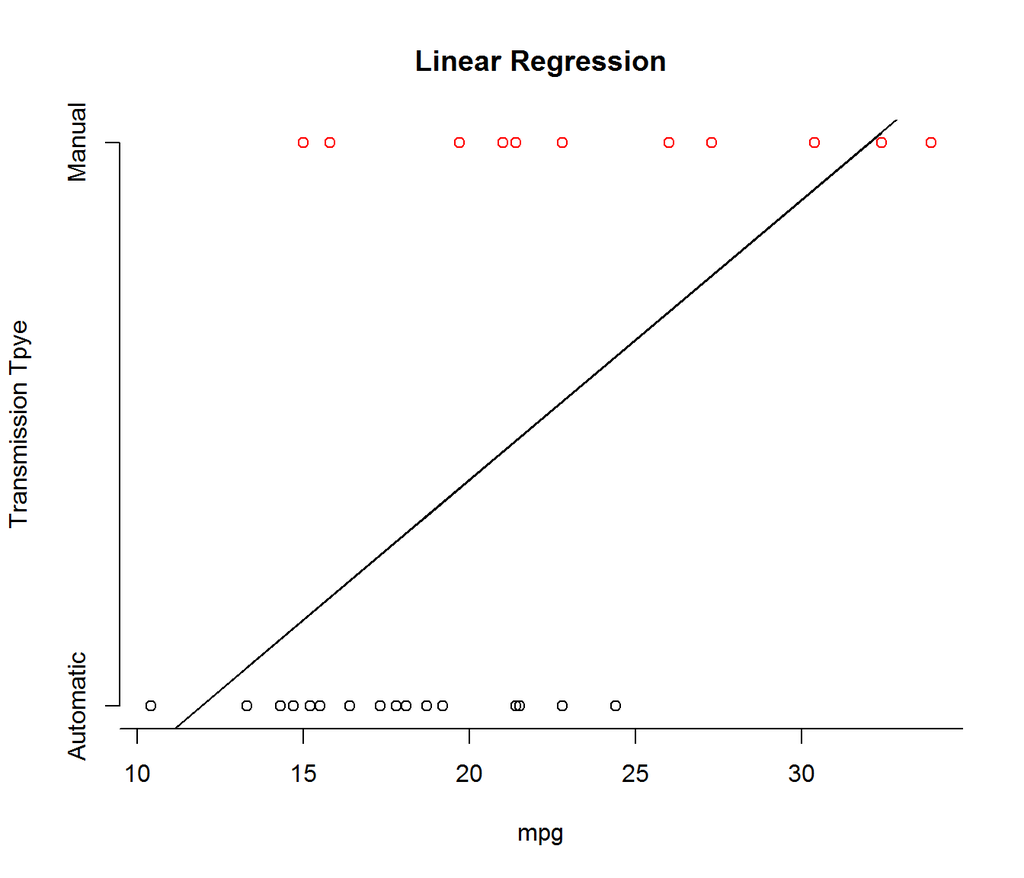

```r
plot(mtcars$mpg,mtcars$am.num, col = mtcars$am, xlab = "mpg",
     ylab="Transmission Tpye", main = "Linear Regression", axes = FALSE)
axis(2,at = c(0,1), labels = c("Automatic","Manual"))
axis(1,at = seq(0,40,5), labels = seq(0,40,5))
lines(mtcars$mpg,fit$fitted.values) #plot the linear regression
```

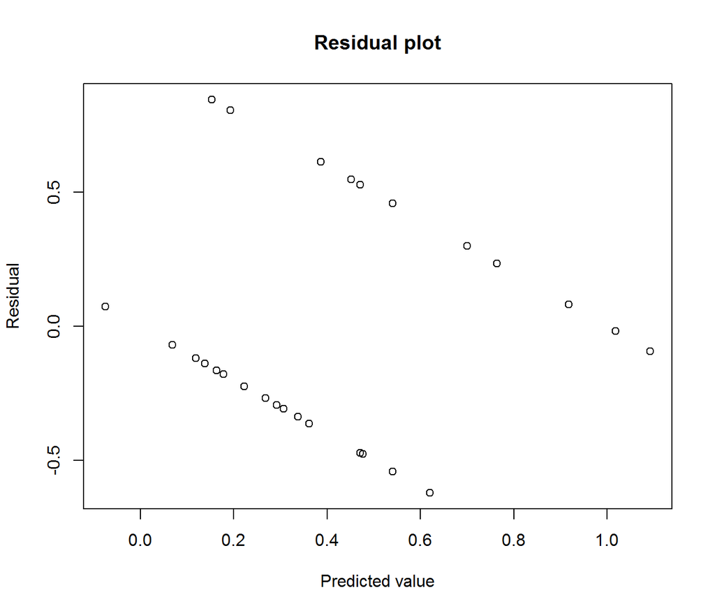

```r
plot(fit$fitted.values,resid(fit), xlab="Predicted value",
     ylab="Residual", main = "Residual plot")
```

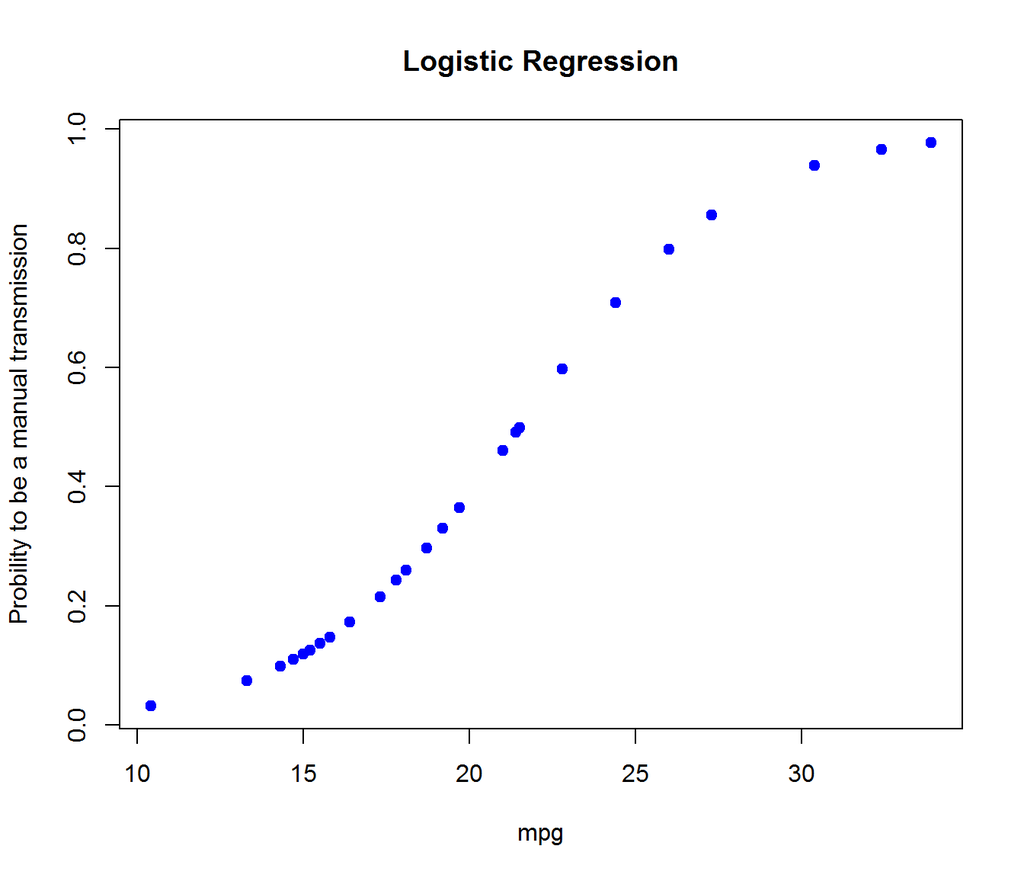

```r
# logistic regression
amglm<-glm(am~mpg, data = mtcars, family = binomial)
plot(mtcars$mpg, amglm$fitted.values,pch=19,col="blue", main = "Logistic Regression",
     xlab = "mpg", ylab="Probility to be a manual transmission")
```

```r
exp(amglm$coeff) #finding odds ration
```

```
## (Intercept)         mpg
## 0.001355579 1.359379288
```

```r
anova(amglm, test = "Chisq") #perform anova test.
```

```
## Analysis of Deviance Table
##
## Model: binomial, link: logit
##
## Response: am
##
## Terms added sequentially (first to last)
##
##
##      Df Deviance Resid. Df Resid. Dev  Pr(>Chi)
## NULL                    31     43.230
## mpg   1   13.555        30     29.675 0.0002317 ***
## ---
## Signif. codes:  0 '***' 0.001 '**' 0.01 '*' 0.05 '.' 0.1 ' ' 1
```

### Response

In the results of linear regreeion, although the summary of fit show that the variable and the fit are significant with alpha = 0.05, the residual plot shows a pattern. Since the transimission tpye is a binary, logistic regression should be a better model.